# Big Data & Business Intelligence

11. Finding Patterns - Market Basket Analysis Using Association Rules

Wen-Bin Chuang

Recommendation systems that data learning has been increasingly applied to learn purchasing patterns. It is commonly known as **market basket analysis** due to the fact that it has been so frequently applied to supermarket data.

You can learn - Using simple measures to **find association**s in large databases. - Understanding the peculiarities of transactional data. - Knowing how to identify the useful and actionable patterns.

# Understanding Association Rules

- A market basket analysis is a **collection of association rules** that specify patterns found in the relationships among items(itemsets).
- Association rules are always composed from subsets of itemsets.
- They are helpful for finding patterns in many different types of data.

Other potential applications include: - Patterns of DNA - Patterns of purchases or medical claims - Cellular phone service

# Apriori Algorithm

Transactional datasets are extremely large, both in terms of the **number of transactions** as well as the **number of items or features** that are monitored.

The number of potential itemsets grows **exponentially** with the number of features. Given $k$ items that can appear or not appear in a set, there are $2^k$ possible **itemset**s that could be potential rules.

A smarter rule learning algorithm takes advantage of the fact that, in reality, many of the potential combinations of items are **rarely**, if ever, found in practice.

For instance, a set of {motor oil, lipstick} is likely to be extraordinarily uncommon. it is possible to limit the scope of the search for rules to a more manageable size.

The most-widely used approach for efficiently searching large databases for rules is known as **Apriori**. Introduced in 1994 by Rakesh Agrawal and Ramakrishnan Srikant.

### Measuring Rule Interest – Support and Confidence

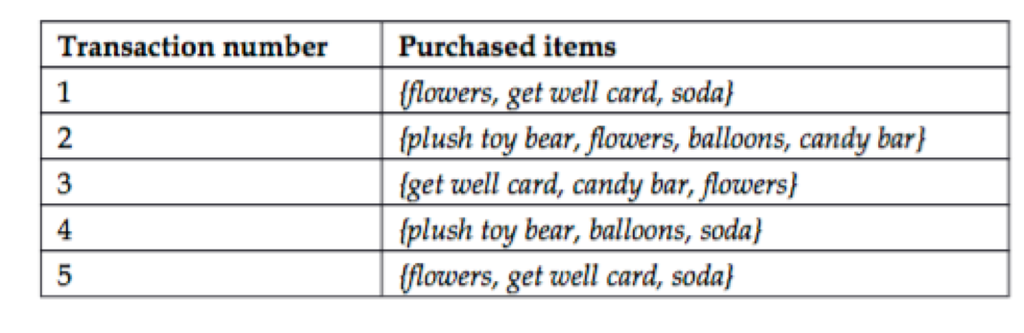

The support of an itemset measures **how frequently it occurs in the data**. For instance the itemset {get well card, flowers} has support of 3 / 5 = 0.6
$$support(x) = \frac{count(x)}{N}$$

Here, $N$ is the number of transactions in the database and $count(X)$ is the number of transactions containing itemset $X$.

A rule’s confidence is a measurement of its predictive power or accuracy. It is defined as **the support of the itemset containing both X and Y** divided by the support of the itemset containing only X:

$$confidence\left(x\rightarrow y\right)=\frac{support\left(x,y\right)}{support\left(x\right)}$$

The confidence tells us the proportion of transactions where the presence of item or itemset $X$ results in the presence of item or itemset $Y$.

For example, the confidence of {flowers} → {get well card} is 0.6 / 0.8 = 0.75. In comparison, the confidence of {get well card} → {flowers} is 0.6 / 0.6 = 1.0.

This means that a purchase involving owers is accompanied by a purchase of a {get well card} 75 percent of the time, while a purchase of a get well card is associated with owers 100 percent of the time.

Rules like {get well card} → {flowers} are known as strong rules, because they have both high support and confidence.

By the way, the lift of a rule is the ratio of the observed support to that expected if X and Y were independent.

### AIS Algorithm (It was the first algorithm in a transaction database)

1. Candidate itemsets are generated and counted on-the-fly as the database is scanned.
2. For each transaction, it is determined which of the large itemsets of the previous pass are contained in this transaction.
3. New candidate itemsets are generated by extending these large itemsets with other items in this transaction.

Assumed that support min = 0.25 (number of transaction > 1 !!!!)

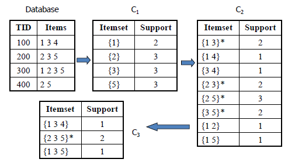

The disadvantage of the AIS algorithm is that it results in unnecessarily generating and counting too many candidate itemsets that turn out to be small.